# Practical Machine Learning Project

Mohammad Masjkur

## Background

Using devices such as Jawbone Up, Nike FuelBand, and Fitbit it is now possible to collect a large amount of data about personal activity relatively inexpensively. These type of devices are part of the quantified self movement - a group of enthusiasts who take measurements about themselves regularly to improve their health, to find patterns in their behavior, or because they are tech geeks. One thing that people regularly do is quantify how much of a particular activity they do, but they rarely quantify how well they do it. In this project, we use data from accelerometers on the belt, forearm, arm, and dumbell of 6 participants. They were asked to perform barbell lifts correctly and incorrectly in 5 different ways. Given data from accelerometers, the goal is to predict the class of action which is one of the following:

- exactly according to the specification (A)
- throwing elbows to the front (B)
- lifting the dumbbell only halfway (C)
- lowering the dumbbell only halfway (D)
- throwing the hips to the front (E).

More information is available from the website here: http://groupware.les.inf.puc-rio.br/har (see the section on the Weight Lifting Exercise Dataset).

## Data Sources

The training data for this project is available here:  
https://d396qusza40orc.cloudfront.net/predmachlearn/pml-training.csv  
The test data is available here:  
https://d396qusza40orc.cloudfront.net/predmachlearn/pml-testing.csv

## Reading Data

```r
UrlTrain <- "http://d396qusza40orc.cloudfront.net/predmachlearn/pml-training.csv"
UrlTest  <- "http://d396qusza40orc.cloudfront.net/predmachlearn/pml-testing.csv"

training <- read.csv("pml-training.csv")
testing  <- read.csv("pml-testing.csv")
dim(training)
```

```
## [1] 19622   160
```

```r
dim(testing)
```

```
## [1]  20 160
```

The training data set contains 19622 observations and 160 variables, while the testing data set contains 20 observations and 160 variables. The `classe` variable in the training set is the outcome to predict.

## Cleaning Data

Those variables have plenty of NA, that can be removed with the cleaning procedures as follows. The Near Zero variance (NZV) variables are also removed and the ID variables as well.

```r
NZV <- nearZeroVar(training)
training <- training[, -NZV]
testing  <- testing[, -NZV]
dim(training)
```

```
## [1] 19622   100
```

```r
dim(testing)
```

```
## [1]  20 100
```

```r
# remove variables that are mostly NA
AllNA    <- sapply(training, function(x) mean(is.na(x))) > 0.95
AllNA    <- sapply(testing, function(x) mean(is.na(x))) > 0.95
training <- training[, AllNA==FALSE]
testing  <- testing[, AllNA==FALSE]
dim(training)
```

```
## [1] 19622    59
```

```r
dim(testing)
```

```
## [1] 20 59
```

```r
# remove identification only variables (columns 1 to 5)
training <- training[, -(1:5)]
testing  <- testing[, -(1:5)]
dim(training)
```

```
## [1] 19622    54
```

```r
dim(testing)
```

```
## [1] 20 54
```

The cleaned training data set contains 19622 observations and 54 variables, while the testing data set contains 20 observations and 54 variables.

## Correlation Analysis

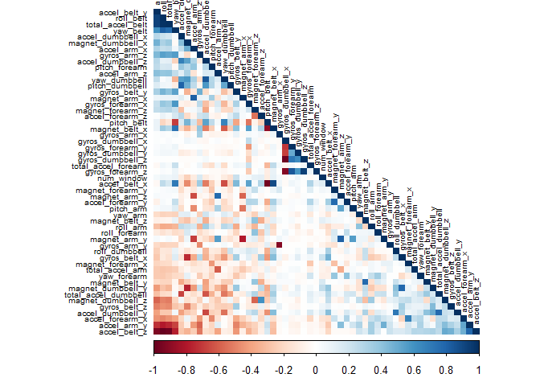

```r
corMatrix <- cor(training[, -54])
corrplot(corMatrix, order = "FPC", method = "color", type = "lower",
         tl.cex = 0.6, tl.col = 'black')
```

Positive correlations are displayed in blue and negative correlations in red color. There is also insignificant correlation (less large intensity color blocks) among the variables.

## Partitioning Training Set

we split the cleaned training set into a pure training data set (70%) and a validation data set (30%). We will use the validation data set to conduct a cross validation.

```r
inTrain  <- createDataPartition(training$classe, p=0.7, list=FALSE)
Trainset <- training[inTrain, ]
ValidTest  <- training[-inTrain, ]
dim(Trainset)
```

```
## [1] 13737    54
```

```r
dim(ValidTest)
```

```
## [1] 5885   54
```

The Dataset consists of the observations as follows:  
1. Training Data: 13737 observations.  
2. Testing Data: 5885 observations.

## Prediction Modeling

### Decision Tree

We build a predictive model for activity recognition using **Decision Tree** algorithm.

```r
modFitDecTree <- rpart(factor(classe) ~ ., data=Trainset, method="class")
fancyRpartPlot(modFitDecTree)
```

[output not shown]